# Ongepaarde t-toets

*In dit document wordt uitgelegd hoe een toetspagina geschreven wordt. Het is gebaseerd op een echte toetspagina (de ongepaarde t-toets) waar met schuine tekst in alinea’s een toelichting wordt gegeven op alle onderdelen van de toetspagina. De schuine tekst is dus toelichting, de normale tekst is de oorsponkelijk toetspagina.*

*Hierboven wordt de titel van het document neergezet en worden een aantal instellingen opgesteld. Voorbeelden hiervan zijn de drie documenten nocache.html (om te voorkomen dat de website in het cache geheugen komt), favicon.html (om de favicon bij het webadres te hebben) en analytics.html (de Matomo tracker die het aantal bezoekers bijhoudt).*

*Hieronder is het eerste CLOSEDBLOK zichtbaar. In het CLOSEDBLOK Functies.R wordt met code ervoor gezorgd dat het script 00. Voorbereidingen.R gerund wordt, zodat alle voorbereidingen voor het schrijven van een toetspagina gedaan worden. Dit bestaat onder andere uit het laden en indien nodig installeren van packages en het laden van zelfgeschreven functies.*

*Hieronder is er het tweede CLOSEDBLOK. In dit CLOSEDBLOK met de naam CSS wordt de stijlsheet Stylesheet_SHHO.css uit de map SHHO/01. Includes/css ingelezen. Deze stylesheet zorgt voor de opmaak van de toetspagina.*

*Hieronder is het CLOSEDBLOK met de naam Header.R te vinden. Dit CLOSEDBLOK zorgt ervoor dat het script Header.R uit de map SHHO/01. Includes/code wordt ingeladen. Dit script zorgt ervoor dat er bovenaan de toetspagina een header komt te staan met daarin de kopjes die ook op de website zichtbaar zijn. Voor een toelichting, zie het script Header.R.*

*Hieronder is het CLOSEDBLOK met de naam Status.R te vinden. Dit CLOSEDBLOK zorgt ervoor dat het script Status.R uit de map SHHO/01. Includes/code wordt ingeladen. Dit script zorgt ervoor dat er een disclaimer onder de titel komt te staan als de toetspagina nog niet door het hele reviewproces heen is gegaan. Als dat wel zo, komt de disclaimer er niet te staan.*

Disclaimer: Het peer review proces voor deze toets is nog niet afgerond; daarom is deze pagina nog in concept.

*Hieronder is het CLOSEDBLOK Reticulate.R te vinden. Dit CLOSEDBLOK heeft voor de R toetspagina geen functie, maar in de Python toetspagina wordt hier het package reticulate ingeladen. Dit package zorgt voor een verbinding tussen R en Python. Het is ook in de R toetspagina zichtbaar, omdat het dus nodig is in de Python toetspagina.*

*De CLOSEDBLOKKEN hierboven zijn allemaal precies hetzelfde in elke toetspagina. Elke toetspagina begint hiermee.*

*Hieronder is het eerste OPENBLOK te vinden. Het OPENBLOK heet Data-aanmaken.R en runt het script 03.R in de map SHHO/01. Includes/data. In dit script wordt een dataset gesimuleerd die gebruikt wordt om de toets mee te illustreren. Dit is ooit een OPENBLOK genoemd, maar zou beter een CLOSEDBLOK genoemdn kunnen worden, omdat de code niet zichtbaar is in de toetspagina. Dit blok is in elke toetspagina aanwezig, maar het script dat aangeroepen wordt is specifiek voor elke toetspagina. Elke toetspagina heeft een eigen data simulatiescript.*

*Nu begint de tekst van de toetspagina. Het eerste hoofdstuk is de toepassing. Hier wordt in een paar zinnen uitgelegd waarvoor de statistische toets gebruikt kan worden. Merk hier op dat de naam van de toets van de toetspagina altijd schuingedrukt is. Er is ook een voetnoot opgesteld. Een voetnoot kan je aanmaken met `[^1]`, waarbij deze voetnoot verwijst naar voetnoot 1 onderaan de toetspagina.*

# 1 Toepassing

Gebruik de *ongepaarde t-toets* om de gemiddelden van twee onafhankelijke groepen te vergelijken.[^1]

*Nu komt de onderwijscasus. Met `<div id = "casus">` wordt aangegeven dat er een speciaal vak voor deze tekst gemaakt moet worden. Dit wordt afgesloten met `</div>`. De eerste alinea van de casus bevat de opgestelde casus voor de toets die door de directe begeleider is gereviewd. Daarna komt een alinea die voor elke toetspagina hetzelfde is. Hierin wordt uitgelegd hoe er hypotheses worden opgesteld. Daarna worden de nulhypothese en alternatieve hypothese uitgeschreven.*

# 2 Onderwijscasus

Vanaf 2011 heeft de opleiding Taalwetenschap een Bindend Studieadvies (BSA) die de selectiviteit van het eerste jaar moet vergroten. De studieadviseur vraagt zich af of het gemiddelde cijfer van de opleiding Taalwetenschap op 1 februari, na invoering van het BSA, veranderd is. De data is beschikbaar voor het cohort gestart in 2010 en voor het cohort gestart in 2011.

Dit onderzoek vertaalt zich in de volgende combinatie van hypothesen, waarbij de nulhypothese zo geformuleerd is dat er geen effect of verschil is en de alternatieve hypothese zo geformuleerd is dat er wel een effect of verschil is.

*H<sub>0</sub>*: Het gemiddelde tentamencijfer dat de studenten halen aan de opleiding Taalwetenschap is niet veranderd na de invoer van het BSA, µ<sub>0</sub> = µ<sub>1</sub>

*H<sub>A</sub>*: Het gemiddelde tentamencijfer dat de studenten halen aan de opleiding Taalwetenschap is veranderd na de invoer van het BSA, µ<sub>0</sub> ≠ µ<sub>1</sub>

*Nu worden de assumpties van de ongepaarde t-toets behandeld. Dit hoofdstuk bestaat uit verschillende subparagrafen, aangegeven met een dubbel hekje (`##`). Bij de uitleg over de assumpties wordt uitgelegd wat de assumptie is, hoe je het toetst/onderzoekt en wat je moet doen als er niet voldaan is aan de assumptie.*

# 3 Assumpties

Voor een valide resultaat moet de data aan een aantal voorwaarden voldoen voordat de toets uitgevoerd kan worden.

*De eerste subparagraaf behandeld de assumptie van normaliteit. Merk hier op dat andere toetsen dus ook weer schuingedrukt zijn, net als het symbool n voor het aantal observaties.*

## 3.1 Normaliteit

De *ongepaarde t-toets* gaat ervan uit dat de afhankelijke variabele normaal verdeeld is voor alle groepen. Als elke groep een aantal observaties (*n*) heeft dat groter dan 100 is, ga er dan vanuit dat de *ongepaarde t-toets* robuust genoeg is om uit te voeren zonder dat de afhankelijke variabele een normale verdeling volgt.

Controleer de assumptie van normaliteit met de volgende stappen:  
1. Controleer de afhankelijke variabele per groep visueel met een histogram, een boxplot en een Q-Q plot.  
2. Toets of de afhankelijke variabele voor beide groepen normaal verdeeld is met de *Kolmogorov-Smirnov test* of bij een kleinere steekproef (*n* < 50) met de *Shapiro-Wilk test*.[^2]<sup>,</sup>[^3]

De eerste stap heeft als doel een goede indruk te krijgen van de verdeling van de steekproef. In de tweede stap wordt de assumptie van normaliteit getoetst. De statistische toets laat zien of de verdeling van de observaties van een groep voldoet aan de assumptie van normaliteit. Voor beide groepen moet er voldaan zijn aan de assumptie van normaliteit.

*Hier is het eerste TEKSTBLOK van de toetspagina. Het heeft de naam Link1.R. Dit is een tekstblok omdat er een link in is opgenomen. Er wordt verwezen naar de Mann-Whitney U toets. Dit is een toets die wordt behandeld in een andere toetspagina en daarom kan er een link naar gemaakt worden. Zo kan er door de gebruiker direct doorgeklikt worden naar die toetspagina op de website. Een link in markdown is te maken met `[Tekst](link)` waarin tussen blokhaken de tekst wordt gezet en tussen gewone haken de link. Hier wordt gelinkt naar de pagina `08-Mann-Whitney-U-toets-R.html` wat het html-bestand van de toetspagina is. Dit is dus een tekstblok, omdat dit voor de Python toetspagina anders moet zijn. Op de Python toetspagina moet gelinkt worden naar de Python toetspagina van de Mann-Whitney U toets, dus `08-Mann-Whitney-U-toets-Python.html`. Deze alinea verschilt dus tussen de R en Python toetspagina en wordt daarom in een TEKSTBLOK gezet. Merk verder op dat hier een dubbele bronvermelding is. Er kunnen twee voetnoten naast elkaar worden gezet door ze te scheiden met `<sup>, </sup>`. Er komt dan een komma tussen beide voetnoten te staan.*

Als blijkt dat de afhankelijke variabele niet normaal verdeeld is voor één van of allebei de groepen, transformeer[^4] dan de afhankelijke variabele en bepaal daarna of deze wel normaal verdeeld is of gebruik de Mann-Whitney U toets.[^5]<sup>,</sup>[^6]

*Dit is de tweede subparagraaf. Hierin wordt een uitleg gegeven over het wel of niet gebruiken van gepoolde variantie.*

## 3.2 Wel of geen gepoolde variantie

De *ongepaarde t-toets* kan met en zonder gepoolde variantie uitgevoerd worden. Bij een gepoolde variantie is de berekening van de variantie van het verschil in gemiddelden anders en wordt aangenomen dat de varianties van beide steekproeven even groot zijn. Deze aanname is te toetsen met de *Levene’s test*, waarbij een significant resultaat aangeeft dat er een verschil is in de varianties van beide groepen. De hedendaagse consensus is echter om altijd deze aanname niet te toetsen en de *ongepaarde t-toets* zonder gepoolde variantie uit te voeren.[^7] Een gepoolde variantie zorgt ervoor dat het onderscheidend vermogen[^8] van de *ongepaarde t-toets* iets hoger is als de varianties van beide groepen ongeveer gelijk zijn, maar geeft verkeerde resultaten als de varianties van elkaar afwijken. Daarnaast heeft *Levene’s test* een laag onderscheidend vermogen, wat betekent dat het lastig is om ongelijke varianties goed te toetsen. Gebruik daarom de *ongepaarde t-toets* zonder gepoolde variantie; deze staat ook wel bekend als *Welch’s t-toets*.[^9]

*Nu begint de uitvoering. In dit hoofdstuk wordt de toets uitgevoerd met programmeercode, in dit geval in programmeertaal R.*

# 4 Uitvoering

*In het begin wordt de dataset geïntroduceerd. Dit is een tekstblok omdat de dataset in Python code een andere naam heeft.*

Er is een dataset ingeladen met gemiddelde cijfers van eerstejaarsstudenten bij de opleiding Taalwetenschap: `Cijfers_gemiddeld`. De dataset bevat cijfers van 180 studenten begonnen in 2010 en cijfers van 160 studenten begonnen in 2011.

*De data wordt altijd even bekeken met de functies `head()` en `tail()`.*

## 4.1 De data bekijken

Gebruik `head()` en `tail()` om de structuur van de data te bekijken.

*Hier wordt weer een OPENBLOK gemaakt om de data te bekijken. Een codeblok is in het algemeen te maken door te beginnen met drie keer een apostrof aansluitend met gekromde haken `{}` . Het codeblok wordt weer afgesloten met drie keer een apostrof. In de gekromde haken staat eerst de programmeertaal (r of python) en daarna kan een titel voor het codeblok toegevoegd worden. Deze titel is echter niet per se nodig. Als twee codeblokken in de gekromde haken dezelfde titel hebben, dan geeft het markdown document bij het knitten een foutmelding, dat mag namelijk niet. Leg in comments in de code uit wat je doet, zet voor eeen comment twee hekjes (`##`).*

```r
## Eerste 6 observaties
head(Cijfers_gemiddeld)
```

```
##   Studentnummer Cohort Cijfers
## 1        302256   2010   5.548
## 2        344374   2010   6.520
## 3        302078   2010   5.297
## 4        325370   2010   8.214
## 5        362912   2010   6.695
## 6        335804   2010   5.315
```

```r
## Laatste 6 observaties
tail(Cijfers_gemiddeld)
```

```
##     Studentnummer Cohort Cijfers
## 335        321518   2011   6.247
## 336        317635   2011   7.185
## 337        396683   2011   7.264
## 338        393299   2011   7.132
## 339        362510   2011   5.763
## 340        335445   2011   4.814
```

Selecteer beide groepen en sla deze op in een vector om deze makkelijker aan te kunnen roepen.

```r
Cijfers_2010 <- Cijfers_gemiddeld$Cijfers[Cijfers_gemiddeld$Cohort == "2010"]
Cijfers_2011 <- Cijfers_gemiddeld$Cijfers[Cijfers_gemiddeld$Cohort == "2011"]
```

*Aan het begin van de toetspagina worden vaak wat beschrijvende statistieken genoemd om meer inzicht in de data te krijgen. Per soort toets verschilt het welke beschrijvende statistieken er gepresenteerd worden.*

Inspecteer de data met `length()`, `mean()`en `sd()` om meer inzicht te krijgen in de data.

*Met `<div class="col-container">` wordt er aangegeven dat er met kolommen gewerkt moet worden. `<div class="col">` geeft aan dat er gestart wordt met het vullen van een kolom, `</div>` dat er kolom afgesloten kan worden.*

```r
## Aantallen, gemiddelde en standaarddeviatie 2010
length(Cijfers_2010)
```

```
## [1] 180
```

```r
mean(Cijfers_2010)
```

```
## [1] 6.369189
```

```r
sd(Cijfers_2010)
```

```
## [1] 1.117662
```

```r
## Aantallen, gemiddelde en standaarddeviatie 2011
length(Cijfers_2011)
```

```
## [1] 160
```

```r
mean(Cijfers_2011)
```

```
## [1] 6.462363
```

```r
sd(Cijfers_2011)
```

```
## [1] 1.199976
```

*Hier wordt een CLOSEDBLOK gemaakt met daarin code waarin een aantal beschrijvende statistieken worden opgeslagen. Voor het jaar 2010 en 2011 worden het gemiddelde, de standaardafwijking en het aantal observaties van de afhankelijke variabele opgeslagen. Dit wordt gedaan zodat deze getallen in het vervolg met inline code aangeroepen kunnen worden. Dit wordt hierna toegelicht. Een closedblok wordt op dezelfde manier opgesteld als een openblok. Een verschil is alleen de inhoud van de kromme haken. Naast de programmeertaal r en de titel Var beschrijven t1 is er nog include=FALSE toegevoegd. In markdown zijn er een heleboel opties om codeblokken in te stellen. include=FALSE houdt in dat de code en de output niet weergegeven worden in het html-document, maar dat de code wel gerund wordt. Op deze manier worden de beschrijvende statistieken opgeslagen in objecten die later in de toetspagina gebruikt worden. Hier komt ook de functie Round_and_format() voorbij. Dit is een zelfgeschreven functie die objecten afrondt en het decimaalteken van een punt (.) naar een komma (,) verandert. De functie rondt standaard op twee decimalen af, maar dit kan veranderd worden door als tweede argument van de functie het aantal gewenste decimalen aan te geven.*

*In dit TEKSTBLOK wordt gewerkt met inline code. Inline code is R code die gerund kan worden, maar gewoon in een tekstregel verschijnt. Inline code wordt gemaakt door te beginnen en te eindigen met één apostrof, daarbinnen te beginnen met de programmeertaal (R in dit geval) en daarna de code die gerund moet worden op te schrijven. Bijvoorbeeld r vMean_t0 betekent dat programmeertaal R gebruikt wordt en dat de uit te voeren code het object vMean_t0 is. Je kan ook functies in de uit te voeren code zetten, een voorbeeld hiervan zou zijn Round_and_format(vMean_t0) om het object te bewerken met de zelfgeschreven functie Round_and_format().*

- Gemiddeld tentamencijfer 2010 (standaarddeviatie): 6,37 (1,12). *n* = 180.
- Gemiddeld tentamencijfer 2011 (standaarddeviatie): 6,46 (1,2). *n* = 160.

## 4.2 Visuele inspectie van normaliteit

Geef de verdeling van de tentamencijfers van beide groepen visueel weer met een histogram, Q-Q plot en boxplot.

*In deze sectie worden visualisaties weergegeven. In het SH houden we aan dat er geen tidyverse code gebruikt wordt, maar zoveel mogelijk base R code. Visualisaties is echter een uitzondering, hier kan ook tidyverse code gebruikt worden. Hier zijn er bijvoorbeeld visualisaties met ggplot gemaakt, maar ook met de gebruikelijke base R functies.*

### 4.2.1 Histogram

*De twee zinnen hieronder zijn standaardzinnen die bij een histogram gebruikt worden. Ze zijn zo opgesteld naar aanleiding van feedback van verschillende reviewers.*

Focus bij het analyseren van een histogram[^10] op de symmetrie van de verdeling, de hoeveelheid toppen (modaliteit) en mogelijke uitbijters. Een normale verdeling is symmetrisch, heeft één top en geen uitbijters.[^11]<sup>,</sup>[^12]

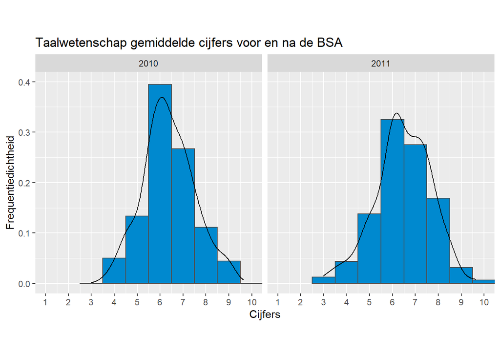

```r
## Histogram met ggplot2
library(ggplot2)

ggplot(Cijfers_gemiddeld,
  aes(x = Cijfers)) +
  geom_histogram(aes(y = ..density..),
                 binwidth = 1,
                 color = "grey30",
                 fill = "#0089CF") +
  facet_wrap(~ Cohort) +
  geom_density(alpha = .2, adjust = 1) +
  ylab("Frequentiedichtheid") +
  scale_x_continuous(
    labels = as.character(seq(1, 10)),
    breaks = seq(1, 10)) +
  coord_fixed(ylim = c(0, 0.4),
              xlim = c(1, 10),
              ratio = 22) +
  labs(title = "Taalwetenschap gemiddelde cijfers voor en na de BSA")
```

Beide histogrammen laten een verdeling zien die redelijk symmetrisch is, één top heeft en geen uitbijters. Daarom zijn beide verdelingen bij benadering normaal verdeeld.

### 4.2.2 Q-Q plot

Gebruik `qqnorm()` en `qqline()` met `pch = 1`om een Q-Q plot te maken, met als datapunten kleine cirkels.

Als over het algemeen de meeste datapunten op de lijn liggen, kan aangenomen worden dat de data normaal verdeeld is.

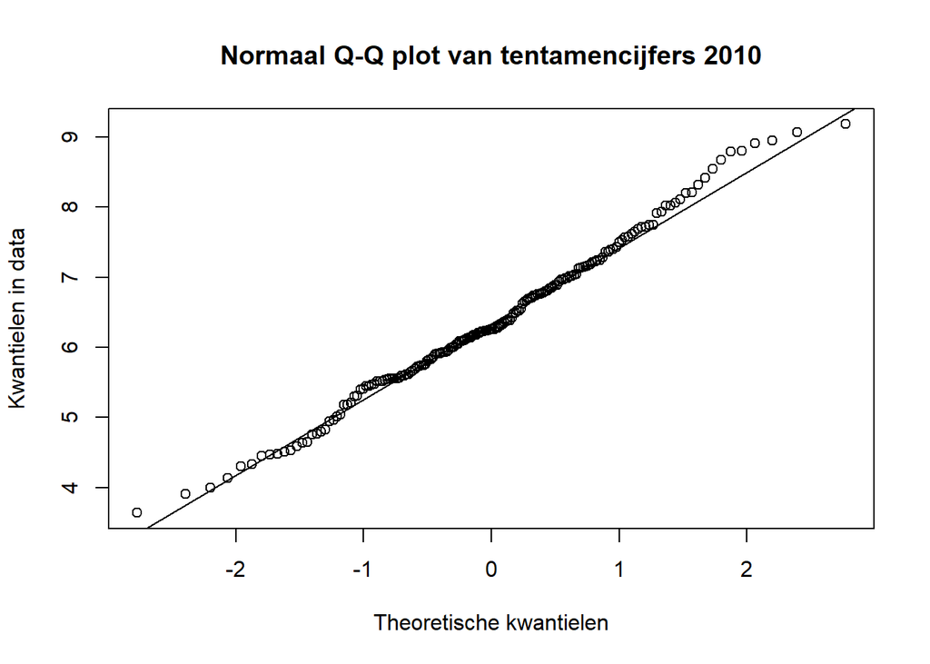

```r
qqnorm(Cijfers_2010, pch = 1,
       main = "Normaal Q-Q plot van tentamencijfers 2010",
       ylab = "Kwantielen in data",
       xlab = "Theoretische kwantielen")
qqline(Cijfers_2010)
```

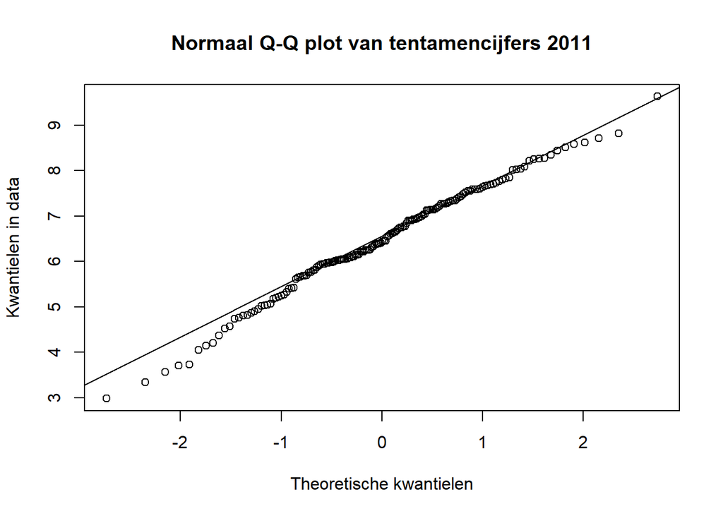

```r
qqnorm(Cijfers_2011, pch = 1,
       main = "Normaal Q-Q plot van tentamencijfers 2011",
       ylab = "Kwantielen in data",
       xlab = "Theoretische kwantielen")
qqline(Cijfers_2011)
```

Voor beide Q-Q plots liggen de meeste datapunten op of vlakbij de lijn. Hoewel er bij de uiteinden van de verdeling wat afwijkingen zijn, duidt deze grafiek op een goede benadering van de normaalverdeling voor beide cohorten.

### 4.2.3 Boxplot

De box geeft de middelste 50% van de tentamencijfers weer. De zwarte lijn binnen de box is de mediaan. In de staarten of snorreharen zitten de eerste 25% en de laatste 25%. Cirkels visualiseren mogelijke uitbijters.[^13] Hoe meer de boxen overlappen, hoe waarschijnlijker er geen significant verschil is tussen de groepen.

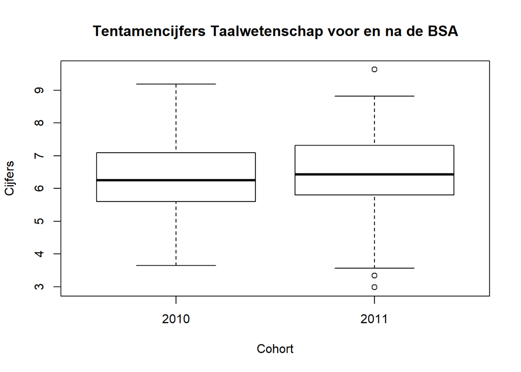

```r
boxplot(Cijfers ~ Cohort, Cijfers_gemiddeld,
        main = "Tentamencijfers Taalwetenschap voor en na de BSA")
```

De boxplotten geven de spreiding weer van het gemiddelde tentamencijfer voor de BSA en na de BSA. De boxplotten en de staarten lijken symmetrisch, wat een teken is van een bij benadering normale verdeling. Het cohort van 2011 heeft een aantal mogelijke uitbijters.[^14]

## 4.3 Toetsen van normaliteit

Om te controleren of de afhankelijke variabele voor beide groepen normaal verdeeld is, kan de normaliteit getoetst worden. Twee veelgebruikte toetsen zijn: de *Kolmogorov-Smirnov test* en de *Shapiro-Wilk test*.

### 4.3.1 Kolmogorov-Smirnov

De *Kolmogorov-Smirnov test* toetst het verschil tussen twee verdelingen. Standaard toetst deze test het verschil tussen een normale verdeling en de verdeling van de steekproef. De Lilliefors correctie is vereist als het gemiddelde en de standaardafwijking niet van tevoren bekend of bepaald zijn, wat meestal het geval is bij een steekproef. Als de p-waarde kleiner dan 0,05 is, is de verdeling van de steekproef significant verschillend van de normale verdeling.

```r
library(nortest)
```

```r
lillie.test(Cijfers_2010)
```

```
##
##  Lilliefors (Kolmogorov-Smirnov) normality test
##
## data:  Cijfers_2010
## D = 0.05404, p-value = 0.2244
```

```r
lillie.test(Cijfers_2011)
```

```
##
##  Lilliefors (Kolmogorov-Smirnov) normality test
##
## data:  Cijfers_2011
## D = 0.061106, p-value = 0.1526
```

Bij deze casus is van beide groepen de p-waarde groter dan 0,05, dus er zijn geen significante verschillen gevonden tussen de verdeling van de steekproef en de normale verdeling. De *ongepaarde t-toets* kan uitgevoerd worden.

### 4.3.2 Shapiro-Wilk Test

De *Shapiro-Wilk test* is een soortgelijke test als de *Kolmogorov-Smirnov test* en vooral geschikt bij kleine steekproeven (*n* < 50). Als de p-waarde kleiner dan 0,05 is, is de verdeling van de steekproef significant verschillend van de normale verdeling.

*Hier worden subsets van de data ingeladen die speciaal gemaakt zijn voor de Shapiro-Wilk test omdat deze geschikt is voor kleine datasets Deze zijn ook in het data simuatie script gesimuleerd. Het maken van extra datasets hiervoor wordt alleen gedaan bij de drie toetspagina’s voor de t-toetsen. Bij de andere toetspagina’s gebeurt dat niet.*

Er zijn twee subsets van `Cijfers_gemiddeld` ingeladen: `Cijfers_2010_n30` en `Cijfers_2011_n30`. Beide subsets bevatten 30 studenten. Voor relatief kleine steekproeven als deze is de *Shapiro-Wilk Test* geschikt.

```r
shapiro.test(Cijfers_2010_n30)
```

```
##
##  Shapiro-Wilk normality test
##
## data:  Cijfers_2010_n30
## W = 0.98796, p-value = 0.9765
```

```r
shapiro.test(Cijfers_2011_n30)
```

```
##
##  Shapiro-Wilk normality test
##
## data:  Cijfers_2011_n30
## W = 0.97627, p-value = 0.7202
```

De p-waarde is groter dan 0,05 voor beide groepen, dus er zijn geen significante verschillen gevonden tussen de verdeling van de steekproef en de normale verdeling. De *ongepaarde t-toets* kan uitgevoerd worden.

*Er is aan alle assumpties voldaan, dus nu begint de uitvoering van de toets. Hier worden zoveel mogelijk de base R functies voor gebruikt, maar dit kan niet voor elke toets. Bij de uitvoering wordt de functie genoemd en een eventueel package waar het vandaan komt (als het niet base R is) en worden de argumenten uitgeschreven en uitgelegd.*

## 4.4 Ongepaarde t-toets

Voer een ongepaarde `t.test()` uit met `paired = FALSE` (vanwege de ongepaarde groepen) en `var.equal = FALSE` (omdat de varianties niet per se aan elkaar gelijk zijn). Het eerste argument bestaat uit de afhankelijke variabele `Cijfers` en de groepvariabele `Cohort`.

*Maak een OPENBLOK waarin de code voor de uitvoering zichtbaar is.*

```r
t.test(Cijfers ~ Cohort, Cijfers_gemiddeld,
       paired = FALSE,
       alternative = "two.sided",
       var.equal = FALSE)
```

```
##
##  Welch Two Sample t-test
##
## data:  Cijfers by Cohort
## t = -0.738, df = 326.37, p-value = 0.461
## alternative hypothesis: true difference in means is not equal to 0
## 95 percent confidence interval:
##  -0.3415432  0.1551960
## sample estimates:
## mean in group 2010 mean in group 2011
##           6.369189           6.462363
```

*Maak een CLOSEDBLOK waarin onjecten worden opgeslagen die nodig zijn voor de resultaten later echo = FALSE betekent hier dat de code niet zichtbaar is, maar eventuele resultaten wel en dat de code gewoon gerund wordt. Hier zou dus ook include = FALSE gebruikt kunnen worden. Er zijn echter geen resultaten na het runnen van deze code, dus beide werken hier.*

*Bij de uitvoering van een toets worden de resultaten altijd puntsgewijs opgesomd met bullets. In de rapportage worden ze netjes gerapporteerd, maar hier gaat op deze manier. Je ziet de volgende elementen daarin. Als eerste een regel met daarin de toetsstatistiek, vrijheidsgraden en p-waarde. Daarna een interpretatie van het resultaat wat betreft significantie, dit is altijd in de vorm van De p-waarde is groter/kleiner dan 0,05, dus de H<sub>0</sub> wordt niet/wel verworpen. Bij deze zin staat ook een voetnoot die hetzelfde is in elke toetspagina. In deze voetnoot wordt vermeldt dat het significantieniveau 0,05 is. Vrijheidsgraden worden hier in een aparte bullet behandeld, maar dat is niet per se nodig, ze kunnen ook in de eerste bullet als getal aanwezig zijn. Er wordt ook indien mogelijk een effectmaat genoemd, maar die staat in deze toetspagina hierna vermeld. Verder horen betrouwbaarheidsintervallen aanwezig te zijn als dat mogelijk is. Getallen worden in de toetspagina altijd op twee decimalen afgerond, behalve voor de p-waarde die op drie getallen afgerond wordt. Als een p-waarde echter kleiner is dan 0,001 dan wordt er p < 0,001 geschreven. Als de p-waarde zelfs kleiner dan 0,0001 is, dan is de notatie p < 0,0001. Wederom is hier inline code gebruikt.*

- *t* = -0,74, *p* = 0,461
- De p-waarde is groter dan 0,05, dus de H<sub>0</sub> wordt niet verworpen [^15]
- Vrijheidsgraden: *df* = 326,37, niet gelijk aan aantal observaties min één bij een ongepaarde t-toets zonder gepoolde varianties
- 95%-betrouwbaarheidsinterval: bij het herhalen van het experiment met verschillende steekproeven van de populatie zal 95% van de betrouwbaarheidsintervallen de daadwerkelijke parameter bevatten, het verschil tussen de hoogte van de cijfers voor en na de BSA cursus, µ<sub>verschil</sub> = µ<sub>T2011</sub> - µ<sub>T2010</sub>. In deze casus is het interval tussen -0,34 en 0,16. Aangezien 0 in dit interval zit, is er geen significant verschil tussen beide gemiddelden in 2010 en 2011.
- Het gemiddelde van de steekproef is in 2010 6,37
- Het gemiddelde van de steekproef is in 2011 6,46

*In de toetspagina wordt altijd een uitleg gegeven over de effectmaat, deze staat hieronder. De eerste paar zinnen zijn overal ongeveer hetzelfde en zijn na reviews van de reviewers opgesteld. Daarna wordt de specifieke effectmaat voor de toets geïntroduceerd. Er worden ook altijd criteria genoemd om de effectmaat te interpreteren.*

In dit voorbeeld is de p-waarde groter dan 0,05, dus is een effectmaat uitrekenen onnodig. Pas de volgende stappen toe bij een p-waarde kleiner dan 0,05.

*Hier wordt de effectmaat berekend met bijbehorende toelichting.* Gebruik de functie `cohensD()` van het package `lsr` met de argumenten `Cijfers ~ Cohort` waarbij `Cijfers` de afhankelijke variabele is en `Cohort` de onafhankelijke variabele die de groepen aangeeft, het argument `Cijfers_gemiddeld` dat de dataset aangeeft en het argument `method = unequal` omdat er niet aangenomen wordt dat de varianties aan elkaar gelijk zijn.

```r
library(lsr)
cohensD(Cijfers ~ Cohort, Cijfers_gemiddeld, method = "unequal")
```

```
## [1] 0.08035328
```

*d* = 0.0803533. De sterkte van het effect van het BSA op het cijfer is verwaarloosbaar.

# 5 Rapportage

*Aan het einde van de toetspagina bevindt zich de rapportage. In de rapportage wordt de conclusie van het onderzoek uit de casus opgeschreven. Eerst worden de resultaten van de statistische toets genoemd (op een zoveel mogelijk APA manier) samen met beschrijvende statistieken, bijvoorbeeld in een Tabel. Daarna wordt de conclusie getrokken met betrekking tot de casus. Let op dat de conclusie niet te stellig is. In deze rapportage is de conclusie “Het gemiddelde tentamencijfer lijkt niet veranderd te zijn na de invoering van het BSA”. Omdat een statistische toets gedaan wordt op basis van een steekproef, is er altijd onzekerheid. Vandaar dat er een voorbehoud is gemaakt door het woord “lijkt” te gebruiken.*

Een *ongepaarde t-toets* is uitgevoerd om te toetsen of het gemiddelde tentamencijfer is veranderd na de invoer van het BSA. Het verschil tussen het gemiddelde tentamencijfer van cohort 2010 (*M<sub>2010</sub>* = 6,37, *SD<sub>2010</sub>* = 1,12) en het gemiddelde tentamencijfer van cohort 2011 (*M<sub>2011</sub>* = 6,46, *SD<sub>2011</sub>* = 1,2) is niet significant, *t* = -0,74, *p* = 0,461. Het 95% betrouwbaarheidsinterval voor het verschil tussen het gemiddelde van beide groepen loopt van -0,34 tot 0,16. Het gemiddelde tentamencijfer lijkt niet veranderd te zijn na de invoering van het BSA.

| Cohort | N | M | SD |
| --- | --- | --- | --- |
| 2010 | 180 | 6,37 | 1,12 |
| 2011 | 160 | 6,46 | 1,2 |

*Tabel 1. Groepsgrootte, gemiddeld tentamencijfer en standaarddeviatie per cohort*

*Hier is de footer. In de footer staat uitleg over het Statistisch Handboek als project van de zone studiedata. Ook kunnen alle datasets hier gedownload worden. De precieze inhoud is te vinden in het script dat wordt aangeroepen, Footer.R in de map SHHO/01. Includes/code.*

Deze pagina maakt onderdeel uit van het Statistisch Handboek Studiedata, ontwikkeld binnen de zone Veilig en betrouwbaar benutten van studiedata van het Versnellingsplan. R code is uitgevoerd met R versie 3.6.3; Python code is uitgevoerd in Python 3.7. De gesimuleerde datasets zijn hier te downloaden.  
© 2021 [Versnellingsplan](https://www.versnellingsplan.nl) - Statistisch Handboek Studiedata - Licentie Laatst gewijzigd op:18-03-2021

*Soms is er een bron die wel in de Python toetspagina voorkomt, maar niet in de R toetspagina. Bijvoorbeeld als er in de Python toetspagina iets is wat nader toegelicht moet worden, of een andere bron die gebruikt moet worden. Als dit zo is, dan wordt er een tekstblok aangemaakt om deze voetnoot in de referentielijst te zetten. Dat zie je hieronder.*

[^1]: Van Geloven, N. (25 mei 2016). *T-toets* [Wiki Statistiek Academisch Medisch Centrum](https://wikistatistiek.amc.nl/index.php/T-toets#ongepaarde_t-toets).
[^2]: Laerd statistics. (2018). [Testing for Normality using SPSS Statistics](https://statistics.laerd.com/spss-tutorials/testing-for-normality-using-spss-statistics.php).
[^3]: Normaliteit. (14 juli 2014). [UvA Wiki Methodologiewinkel](https://wiki.uva.nl/methodologiewinkel/index.php/Normaliteit).
[^4]: Er zijn verschillende opties om variabelen te transformeren, zoals de logaritme, wortel of inverse (1 gedeeld door de variabele) nemen van de variabele. Zie *Discovering statistics using IBM SPSS statistics* van Field (2013) pagina 201-210 voor meer informatie over welke transformaties wanneer gebruikt kunnen worden.
[^5]: Van Geloven, N. (13 maart 2018). *Mann-Whitney U toets* [Wiki Statistiek Academisch Medisch Centrum](https://wikistatistiek.amc.nl/index.php/Mann-Whitney_U_toets).
[^6]: De Mann-Whitney U toets maakt een rangschikking van de data. Hierdoor is de test verdelingsvrij en is normaliteit geen assumptie. Ook zijn uitbijters minder van invloed op het eindresultaat. Toch wordt er voor deze test minder vaak gekozen, doordat bij het maken van een rankschikking de data informatie verliest. Als de data wel normaal verdeeld is, heeft de Mann-Whitney U toets minder onderscheidend vermogen dan wanneer de *ongepaarde t-toets* uitgevoerd zou worden.
[^7]: Lakens, D. (26 januari 2015). *Always use Welch’s t-test instead of Student’s t-test*. [The 20% Statistician](http://daniellakens.blogspot.com/2015/01/always-use-welchs-t-test-instead-of.html).
[^8]: Onderscheidend vermogen, in het Engels power genoemd, is de kans dat de nulhypothese verworpen wordt wanneer de alternatieve hypothese ‘waar’ is.
[^9]: Lakens, D. (26 januari 2015). *Always use Welch’s t-test instead of Student’s t-test*. [The 20% Statistician](http://daniellakens.blogspot.com/2015/01/always-use-welchs-t-test-instead-of.html).
[^10]: De breedte van de staven van het histogram wordt vaak automatisch bepaald, maar kan handmatig aangepast worden. Aangezien de breedte van de staven bepalend zijn voor de indruk die de visualisatie geeft, is het verstandig om hier goed op te letten.
[^11]: Outliers (13 augustus 2016). [UvA Wiki Methodologiewinkel](https://wiki.uva.nl/methodologiewinkel/index.php/Outliers).
[^12]: Uitbijters kunnen bepalend zijn voor de uitkomst van toetsen. Bekijk of de uitbijters valide uitbijters zijn en niet een meetfout of op een andere manier incorrect verkregen data. Het weghalen van uitbijters kan de uitkomst ook vertekenen, daarom is het belangrijk om verwijderde uitbijters te melden in een rapport.
[^13]: Outliers (13 augustus 2016). [UvA Wiki Methodologiewinkel](https://wiki.uva.nl/methodologiewinkel/index.php/Outliers).
[^14]: Uitbijters kunnen bepalend zijn voor de uitkomst van toetsen. Bekijk of de uitbijters valide uitbijters zijn en niet een meetfout of op een andere manier incorrect verkregen data. Het weghalen van uitbijters kan de uitkomst ook vertekenen, daarom is het belangrijk om verwijderde uitbijters te melden in een rapport.
[^15]: In dit voorbeeld wordt uitgegaan van een waarschijnlijkheid van 95% c.q. een p-waardegrens van 0,05. De grens is naar eigen inzicht aan te passen; houd hierbij rekening met type I en type II fouten.
[^16]: Field, A., Miles, J., & Field, Z. (2012). *Discovering statistics using R*. London: Sage publications.
[^17]: Marshall, E., & Boggis, E. (2016). *The statistics tutor’s quick guide to commonly used statistical tests*. http://www.statstutor.ac.uk/resources/uploaded/tutorsquickguidetostatistics.pdf.